# A big data analytics model for customer churn prediction in the retiree segment - ScienceDirect

## Outline

1. Highlights
2. Abstract
3. Keywords
4. 1. Introduction
5. 2. Review of literature
6. 3. Rational, hypothesis and objective
7. 4. Method
8. 5. The big data model
9. 6. Analysis and results
10. 7. Conclusion
11. Appendix A.
12. Appendix B. Churn Rate and Online Behavior
13. References

## Figures (19)

[figure not shown]

[figure not shown]

[figure not shown]

## [International Journal of Information Management](https://www.sciencedirect.com/science/journal/02684012)

[Volume 48](https://www.sciencedirect.com/science/journal/02684012/48/supp/C), October 2019, Pages 238-253

# A big data analytics model for customer churn prediction in the retiree segment

[FaridShirazi<sup>a</sup>](https://www.sciencedirect.com/science/article/pii/S0268401218301518?via%3Dihub#!)[MahbobehMohammadi<sup>b</sup>](https://www.sciencedirect.com/science/article/pii/S0268401218301518?via%3Dihub#!)

## Highlights

**•**

Utilizing big [data analytics](https://www.sciencedirect.com/topics/social-sciences/data-analytics) we offered an efficient framework to predict churning decisions.

**•**

Hadoop ecosystem integrated with BI platform allows us to uncover a wealth of data and information.

**•**

We offered an improved Churn Prediction Model using CRT decision tree with big data analytics.

## Abstract

Undoubtedly, the change in consumers’ choices and expectations, stemming from the emerging technology and also significant availability of different products and services, created a highly competitive landscape in various customer service sectors, including the financial industry. Accordingly, the Canadian banking industry has also become highly competitive due to the threats and disruptions caused by not only direct competitors, but also new entrants to the market.

The primary objective of this paper is to construct a predictive churn model by utilizing big data, including the structured archival data, integrated with unstructured data from sources such as online web pages, the number of website visits and phone conversation logs, for the first time in the financial industry. It also examines the effect of different aspects of customers’ behavior on churning decisions. The Datameer big data analytics tool on the Hadoop platform and predictive techniques using the SAS business intelligence system were applied to study the client retirement journey path and to create a churn prediction model. By deploying the above systems, we were able to uncover a wealth of data and information associated with over 3 million customers’ records within the retiree segment of the target bank, from 2011 to 2015.

## Keywords

Big data

Business intelligence

Churn prediction model

Hadoop

Customer lifetime value

Classification

Regression tree

## 1. Introduction

Unarguably, the financial industry is evolving with an increasing magnitude and fast pace, according to the discernable changes in consumers' choices and expectations, which are stemming from the emerging technology and significant availability of different products and services. As a result, the banking industry has also become highly competitive due to all the threats and disruptions caused by not only direct competitors, but also all the new and innovative entrants, such as Apple, Google, and new start-ups. Hence, sustaining a competitive advantage and maintaining the Point of Differentiation (POD), in order to remain in clients' financial paths, is considered one of the highest priorities in strategic planning related to client attraction and more importantly, retention within the retail banking sector.

Despite the fact that different types of Customer Relationship Management (CRM) strategies have been in existence for many decades, it became the center of focus for many researchers and practitioners, after the business world shifted its marketing focus from product-centric strategies towards customer-centric strategies. As a result, the relationships between customers and companies have evolved in a way that many new marketing opportunities have been created (Ngai, 2005). Moreover, customer retention has become one of the main areas on which most of the CRM strategies focus on. As mentioned by Coussement, Benoit, and Poel (2015), one of the cornerstones of CRM is customer churn prediction, where one attempts to predict whether or not a customer will leave the company. Moreover, the churn rate is defined as the annual percentage rate at which customers cease to subscribe to a service or terminate a business relationship.

Reducing the rate of churn and retaining current customers are the most cost-effective marketing approaches that will maximize shareholder’s value (Ekinci et al., 2012; Ngai, Xiu, & Chau, 2009; Ryals & Knox, 2005; Van den Poel & Lariviere, 2004) Asmentioned by Lin, Tzeng, and Chin (2010), with so much competition, companies need to focus on retaining existing customers by effectively satisfying their needs; otherwise, they risk losing their customers; and losing customers offers competitors the opportunities to attract them.

Accordingly, the client retiree segment has been identified as one of the highest client strategic priorities within the Personal and Commercial Banking (P&CB) of "target bank"<sup>1</sup>. In order to own the retirement segment and become the retirement advisor and provider of choice in Canada, a new research project is sponsored by the CRM department, which focuses on “Mass Affluent” pre-retiree, and retiree client segments, which aims to evaluate and examine various marketing approaches towards maximizing retention rates.

Generally, each industry has its definition of the mass affluent segment, but according to the Canadian Banking industry, mass affluent segments include clients who have investable assets between $100,000 [CAD](https://www.sciencedirect.com/topics/social-sciences/computer-aided-design) and $1,000,000 CAD. According to the financial industry, clients who are categorized solely based on their assets, belong to one of the following categories:

**•**

Non-Mass Affluent or Mass Retail: Clients with less than $100,000 investable assets

**•**

Mass Affluent: Clients with investable assets between $100,000 and $1,000,000

**•**

High Net-Worth: Clients with higher than $1,000,000 investable assets

As indicated on the Bank Administration Institute (BAI) report of 2014, mass affluent clients are difficult to be penetrated due to their specific knowledge base, their expectations of the market, and the return on their investments. Therefore, gaining a thorough understanding of their expectations and their investment criteria is necessary to not only successfully attract them but also to retain them (Bank Administration Institute, 2014). For a reason mentioned above, analyzing customers' shopping behavior through big data techniques will provide an opportunity to indicate the products that a specific client has expressed an interest in and has reviewed through external websites. This type of scrutiny provides an opportunity for the marketing team to design and offer customized products and services that a specific client desires. According to Lewis and Soureli, this marketing approach will boost customers' satisfaction and will likely increase the probability of retention in return (Lewis & Soureli, 2006). It is noteworthy that none of the previous churn prediction studies have focused specifically on this multi-billion dollar market.

### 1.1. Background

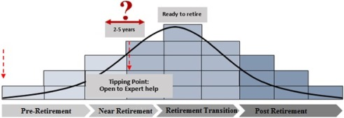

Fig. 1. Client Retirement Journey Path.

Although emerging technologies and the improvement of data mining techniques have made it possible to perform comprehensive studies about customer churn predictions within many industries, including the financial industry, there is an apparent absence of big [data analytics](https://www.sciencedirect.com/topics/social-sciences/data-analytics) in the customer churn prediction. Furthermore, as Chen et al. claimed, big data analytics is being used in many science and technology-driven projects but has received less attention in service industries, such as the financial services (Chen, Chiang, & Storey, 2012).

Since this research study deals with the prediction of customer churn in the financial industry using big data analytics techniques, it will help to fill the analytical gap. The study will contribute to the existing literature through a) developing a customer churn prediction model for the financial sector by using big data analytic techniques, b) building a model based on a dataset which consists of only mass affluent clients from the retiree segment, c) producing multiple outcomes in this model. Compared to most of the existing churn literature, which focus on the binary status of churned and not-churned clients; our proposed model will return four different types of customers: churned, not yet churned (potential clients), partially churned (the second potential client segment), and retained clients. According to the current literature, it is the first study that uses Classification and Regression Tree (CRT) in conjunction with regression analysis for implementing the churn prediction model on big data, incorporating different sources of data.

This paper serves as the preliminary assessment and measurement for the construction of the Churn Prediction Model (CPM).

The remainder of this paper is structured in the following order. Section 2 reviews the existing literature, while Section 3 highlights the rationale behind the need for the current research study, and is followed by the main question and a list of hypotheses. Section 4 will explain the research approach, data population, and all the cues that are utilized to predict the churn event for each client category within the population of this study. In Section 5 we will explain our big data model followed by Section 6, which outlines a comprehensive discussion regarding the above findings, along with the limitations and strengths of this study. Finally, in Section 7, a detailed conclusion along with all the recommendations is stated, which the target bank’s Marketing Strategy team will use.

## 2. Review of literature

For the scope of this paper, the literature studies are categorized into three main groups: 1) Customer Lifetime Value (CLV) measurement: to indicate the best available model for creating the population dataset for this study, 2) churn predictive indicators and models: in order to locate the most relevant indication factors in a churn event, 3) attrition analysis methods: which will be used as part of the final recommendation made to the marketing executives, in order to design a sound retention campaign for customers who are identified as potential clients.

### 2.1. Customer lifetime value

Customer Lifetime Value (CLV) is a total of net value that a single client possesses for the company over the lifetime of their relationship (Hoekstra & Huizingh, 1999). For example, in this study, CLV is measured based on the net value each client possesses for the bank, from the beginning of their banking relationship.

More than 62% of customer relationship studies are related to customer retention (Ngai et al., 2009). According to current studies, CRM is segmented into two strategies: "Operational" and "Analytical." While operational CRM strategies focus on process automation and optimization, the analytical CRM strategies primarily focus on customer behavioral studies by classifying and analyzing customers' data to provide appropriate guidelines for CRM marketing (Rosset, Neumann, Eick, Vatnik, & Idan, 2002). In general, CRM can be classified into four major dimensions: customer identification, attraction, retention, and development (Ngai et al., 2009; Au, Chan, & Yao, 2003; Kracklauer, Mills, & Seifert, 2004; Ling & Yen, 2001). As mentioned by De Caigny, Coussement, and De Bock (2018) customer churn prediction is an important research discipline within a CRM context. It introduces not only loss in profit but also imposes other adverse effects on the operation of a business; such as the increased cost of attracting new customers and loss of up sale opportunities (De Caigny et al., 2018). As such, it is not surprising that the customer relationship management and more specifically customer retention, has received a growing amount of attention (Verbeke, Martens, & Baesens, 2014) in recent years.

Current studies also confirm that six different data mining algorithms are widely used by CRM researchers (Ngai et al., 2009). This paper is mainly focused on the assessment of the association rule, regression analysis, and the decision tree. Stated applied algorithms are also suggested for big [data analytics](https://www.sciencedirect.com/topics/social-sciences/data-analytics) (Chen et al., 2012). By analyzing customers’ behavior, firms will be able to predict a churn event and identify potential churners to design a customized incentive program as part of the retention strategies (Ngai et al., 2009). Likewise, as indicated by Ekinci, Uray, and Ülengin (2014), in order to address the drawback of previous literature in measuring a customer’s lifetime value, the measurement must be modeled based on the product and industry-specific indicators.

### 2.2. Churn prediction, indicators and models

Although different methods return different accuracy rates, selecting the right method for our churn prediction model significantly impacts how accurate the outcome would be. Therefore, detecting the accuracy of the defection rate is a noticeable objective for many studies to define the best churn prediction model (Neslin, Gupta, Kamakura, Lu, & Mason, 2006). As argued by Verbeke, Martens, Mues, and Baesens (2011), the accuracy of the churn prediction model allows the company to target future churners in a retention marketing campaign correctly.

On the one hand, current studies confirm that models have staying power for at least three months because it has been proven that the result of the current churn models remains valid for approximately three months after each run (Neslin et al., 2006). Alternately, the cost of maintaining and running the churn prediction models on a regular basis is significantly high for companies, including banks. Hence, a more in-depth analysis was conducted as part of this study to validate the above findings. After performing the constructed churn model in different periods and comparing the results, we were able to confirm that the three months staying power is also applicable to bank customers. This finding will be reflected in the final recommendations of this study.

Out of the five distinct estimation and variable selection techniques which are used in the churn prediction models, the logistic and decision-tree approaches, perform relatively well compared with other techniques (Moro, Cortez, & Rita, 2014; Neslin et al., 2006). For this study, a decision tree is used to confirm the results of the churn model and the probability of each churn event. The decision tree is a familiar technique and has had many successful applications to real-world problems, due to its symbolic learning technique that organizes information extracted from a training dataset (Nie, Rowe, Zhang, Tian, & Shi, 2011). It can build models using datasets, including numerical and categorical data (Nie et al., 2011).

With this background and confirmation that the selected method will significantly impact the accuracy of the results, more papers regarding different churn prediction methods were evaluated, in order to find the most suitable technique for the current research. For example, by reviewing the most distinguished work of Verbeke et al. (2011), it is confirmed that correct and accurate results of churn models increase the effectiveness of a retention campaign (Neslin et al., 2006; Prasad & Madhavi, 2012; Verbeke et al., 2011).

Verbeke et al. (2011) compared two commonly used techniques in predicting customer churns Active Learning Based Approach (ALBA) and AntMiner+. They also included traditional rule-based classification techniques, such as C4.5 and Repeated Incremental Pruning to Produce Error Reduction (RIPPER) and confirmed the findings of previous literature that AntMiner + is the most comprehensible classification technique since it allows for adding of domain knowledge as customized rule-set variables (Verbeke et al., 2011). Their work also supported the finding of Prasad and Madhavi's research (2012) that C4.5 and C5 (higher version of 4.5) are not the best performing classification decision trees because C4.5 and its next-generation C5, require more information and use a large number of nodes, which makes the model very complex. Therefore, AntMiner + techniques are used to classify the customer segmentation in the current study. However, since the AntMiner + algorithm is based on the binary method, and this research is building a multi-result model, we combined AntMiner + techniques with [Neural Network](https://www.sciencedirect.com/topics/social-sciences/neural-network) analysis in order to create multi-level customer segmentation.

Evaluating various churn prediction models using data mining techniques such as C5 and in comparison with the Classification and Regression Tree Techniques revealed that CRT returns a higher rate of accuracy (Prasad & Madhavi, 2012; Verbeke et al., 2011).

### 2.3. Attrition analysis methods

In terms of defining a churn prediction model with high rates of accuracy, the proportional hazard technique, which is a class of survival analysis, is being used by many researchers, primarily because this model not only enables the prediction of the churn event, but it also ascertains the time of the churn (Van den Poel & Lariviere, 2004). Current literature indicates that demographic and environmental changes have significant impacts on retention (Van den Poel & Lariviere, 2004), whereas customer behavior predictors reflect only a limited impact. Although our study partially rejects this theory as the behavioral factors considered in previous works were only internal data, such as paying off all the credit debts and mortgages or enquiring with financial planners in banks about available options. On the contrary, this study outlines the online behavior of customers on external websites and products are analyzed to identify the correlation between customers’ behavior and the churn decision. The findings of this research confirm that slowing down the banking relationship is an indication of churn; however, compared to online shopping behavior, this factor is more significant within the retiree segment, as compared to the non-retiree segment.

## 3. Rational, hypothesis and objective

### 3.1. Rational

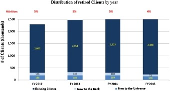

Fig. 2. Distribution of retired clients 2012–2015.

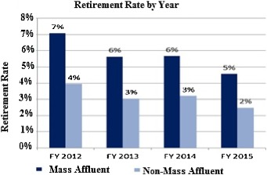

Fig. 3. Retirement rate 2012–2015.

The above numbers confirm that mass-affluent clients who have a long history with the bank are more likely to remain loyal for at least a few years after retirement. This result can also be confirmed by looking at Fig. 4, which compares the attrition rate between mass affluent and non-affluent clients, year over year. As demonstrated, the attrition rate of affluent clients’ accounts for 1%, versus that of 7% for non-mass affluent clients. The analysis also exposed that the attrition rate is stable, year over year, which is an essential factor for defining the retention strategy.

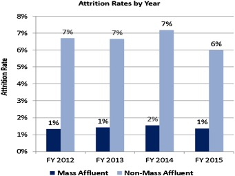

Fig. 4. The attrition rate of Mass Affluent clients vs. Non-Mass Affluent 2012–2015.

Based on the stated facts, designing and implementing a retention strategy for mass affluent clients seems necessary as it will return a higher rate of success by improving and strengthening the relationship with this population. To do so, using the current prediction system of the target bank is not sufficient, and there is a need for understanding the clients' needs and their shopping behavior in order to offer the right product and services. The current research study is being designed to address this objective by answering the main question and stated hypotheses that are outlined in the next section.

### 3.2. Hypothesis

The following main question is going to be addressed in this research: Is there any association between a customer's behavior and the attrition rate?

Our model of Churn prediction for big data underwent two types of prediction modeling; a) using a big data mining approach called Decision Tree with the growing method known as *Classification and Regression Tree* (CRT), and b) deploying the classical General Linear Model (GLM) analysis using SAS system on a selected group based on CRT. Gandomi and Haider (2015) argue that prediction analytics compromise a variety of techniques that predict future outcomes based on historical/archival and current data. These techniques may include the classical linear regression analysis, in conjunction with machine learning tools such as [neural network](https://www.sciencedirect.com/topics/social-sciences/neural-network) and/or data mining techniques such as Decision Tree. In particular, CRT helps big data mining for classification and “segmentation of population into meaningful subsets” (Lemon, Friedmann, & Rakowski, 2003:172). As mentioned by Wei and Chiu (2002), data mining refers to a process of extracting previously unknown, valid and actionable patterns or knowledge from large databases, involving methods at the intersection of machine learning, statistics, and database systems for critical business decision support.

Based on the literature and in order to develop a model for churn prediction using big data techniques, the following hypothetical model, as depicted in Fig. 5, was set up. We investigate the following hypothesis to answer the main question:

**H1**

Churn rate has a significant correlation with the retirement event

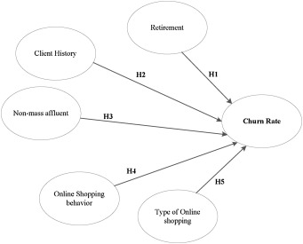

Fig. 5. The hypothetical research model.

As argued by McNeal (1999), a characteristic of the financial services industry is that banking and especially insurance products are perceived as “adults only’’ products (cf. Larivie`re & Van den Poel, 2007). This study investigates the retention proneness of customers during important lifetime events, namely the retirement stage, which is characterized by the need to generate income from previous investments and to maintain the standard of living during the senior years (Larivie`re & Van den Poel, 2007). Based on the historical data, it is known to the target bank that the customer churn rate is correlated with the events of retirement. When it comes to retirement planning, there are steps one may want to take, including but not limited to planning an extended trip abroad, investment plans, a major renovation of the existing property, financing a new vehicle or supporting their children (e.g., education, business start-ups, marriage).

**H2**

The length of the client history has a significant correlation with churn rate.

A long-term customer has been able to establish mutual trust with their financial provider, despite the fact they are not necessarily a loyal customer (Lejeune, 2001). Bhattacharya (1998) argues that the length of time for which one has been a member (a customer) indicates the base level of satisfaction with the organization. Therefore it is expected that the length of customer history with their financial institute is influenced, among others, by the availability of good service, relevant content in an enjoyable and satisfactory context (Khailfa & Liu, 2007; Koufaris, 2002)) and the trust established between the customer and the financial planner. As argued by Kandampully (1998), in order to protect their long-term interest, service organizations such as the target bank are seeking ways to forge and to maintain an ongoing relationship with their customers by offering service loyalty, thereby effecting responsive and sustained patronage.

**H3**

The churn pattern of mass affluent clients is not the same as non-mass affluent.

According to the Bank Administration Institute (BAI) report of 2014, mass affluent clients are difficult to be penetrated due to their specific knowledge base and their expectations of the market and the return on their investments. Therefore, gaining a thorough understanding of their expectations and their investment criteria is necessary to not only successfully attract them but also to retain them (Bank Administration Institute, 2014). As such, it is expected that the mass affluent clients who usually have a stronger relationship with their financial planners remain longer with their financial institutes, compared to the non-mass affluent segment.

**H4**

Customers’ online shopping behavior has a significant correlation with the churn rate.

Koufaris (2002) argues that a fundamental difference between online and offline consumer behavior is that the online consumer is generally more powerful, demanding, and utilitarian in their shopping expeditions. As such, it is expected that the intra-relationship among online customers impact their shopping habits via the process of information sharing. Khailfa and Liu (2007) argue that the effects of online shopping habits on online repurchase intentions are two-fold: (1) mediated through satisfaction and (2) moderating the relationship between satisfactions and repurchase intentions (p.783). As such, it is expected that customers with a high rate of online shopping habits are more likely to search for competitors’ products and churn with a higher rate, compared at the other retiree groups.

**H5**

The type of shopping behavior has a significant correlation with the churn pattern.

A related hypothesis to H4 is the type of online activities namely: online banking (e-banking) and the traditional non-online (i.e., brick-and-mortar) banking. As such, it is expected the attrition rate amongst the non-online banking, retiree segment to be higher than those who used online banking and the information seeking pages. Lassar, Manolis, and Lassar (2005) suggest that the type of consumer innovation matters in understanding the adoption of e-banking processes. This supports the notion that online shoppers are distinct from traditional non-online shoppers since they possess more experience in searching for products and service information online. The empirical study of Dwivedi, Rana, Jeyaraj, Clement, and Williams (2017) found that attitude towards IS/IT innovations plays a central role in the acceptance and use of technology. Also, this implies that individuals may use innovation based on the strength of their attitudes, even though they may not consciously intend to use the innovation (Dwivedi, Rana et al., 2017).